# 01_QualityTrimming

Antone Jung

2025-03-03

# Set seed

```r
set.seed(10202005)
```

# Load libraries

```r
pacman::p_load(tidyverse, dada2, phyloseq, patchwork, DT, devtools, install = FALSE)
```

# Read raw files

```r
raw_fastqs_path <- "../data/01_DADA2/01_raw_gzipped_fastqs"
head(list.files(raw_fastqs_path))
```

```
## [1] "SRR12183139_1.fastq.gz" "SRR12183139_2.fastq.gz" "SRR12183147_1.fastq.gz"
## [4] "SRR12183147_2.fastq.gz" "SRR12183158_1.fastq.gz" "SRR12183158_2.fastq.gz"
```

```r
length(list.files(raw_fastqs_path))
```

```
## [1] 102
```

```r
#split into forward
forward_reads <- list.files(raw_fastqs_path, pattern = "_1.fastq.gz", full.names = TRUE)
head(forward_reads)
```

```
## [1] "../data/01_DADA2/01_raw_gzipped_fastqs/SRR12183139_1.fastq.gz"
## [2] "../data/01_DADA2/01_raw_gzipped_fastqs/SRR12183147_1.fastq.gz"
## [3] "../data/01_DADA2/01_raw_gzipped_fastqs/SRR12183158_1.fastq.gz"
## [4] "../data/01_DADA2/01_raw_gzipped_fastqs/SRR12183176_1.fastq.gz"
## [5] "../data/01_DADA2/01_raw_gzipped_fastqs/SRR12183187_1.fastq.gz"
## [6] "../data/01_DADA2/01_raw_gzipped_fastqs/SRR12183204_1.fastq.gz"
```

```r
length(forward_reads)
```

```
## [1] 51
```

```r
#and reverse
reverse_reads <- list.files(raw_fastqs_path, pattern = "_2.fastq.gz", full.names = TRUE)
head(reverse_reads)
```

```
## [1] "../data/01_DADA2/01_raw_gzipped_fastqs/SRR12183139_2.fastq.gz"
## [2] "../data/01_DADA2/01_raw_gzipped_fastqs/SRR12183147_2.fastq.gz"
## [3] "../data/01_DADA2/01_raw_gzipped_fastqs/SRR12183158_2.fastq.gz"
## [4] "../data/01_DADA2/01_raw_gzipped_fastqs/SRR12183176_2.fastq.gz"
## [5] "../data/01_DADA2/01_raw_gzipped_fastqs/SRR12183187_2.fastq.gz"
## [6] "../data/01_DADA2/01_raw_gzipped_fastqs/SRR12183204_2.fastq.gz"
```

```r
length(reverse_reads)
```

```
## [1] 51
```

# Evaluate seq quality

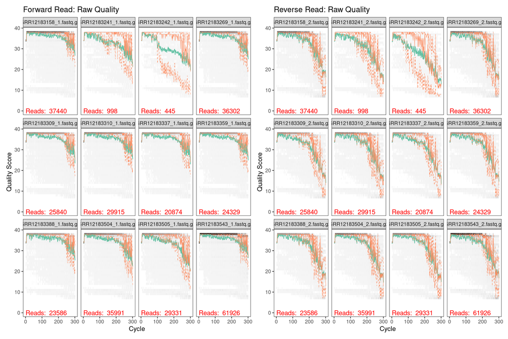

```r
random_sample <- sample(1:length(reverse_reads), size = 12)

forward_filteredQual_plot_12 <- plotQualityProfile(forward_reads[random_sample]) + labs(title = "Forward Read: Raw Quality")
reverse_filteredQual_plot_12 <- plotQualityProfile(reverse_reads[random_sample]) + labs(title = "Reverse Read: Raw Quality")

forward_filteredQual_plot_12 + reverse_filteredQual_plot_12
```

# Aggregate raw quality plots

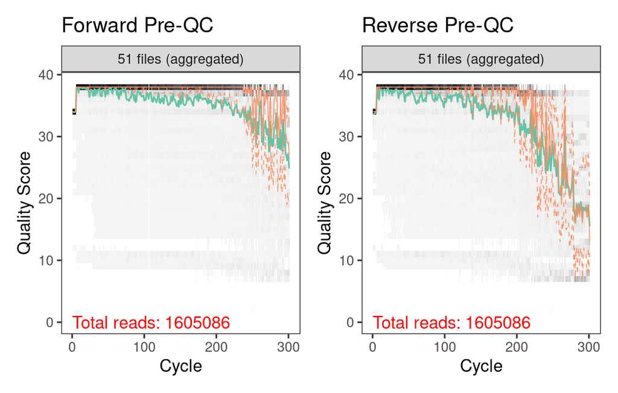

```r
# Aggregate all QC plots
# Forward reads
forward_preQC_plot <-
  plotQualityProfile(forward_reads, aggregate = TRUE) +
  labs(title = "Forward Pre-QC")

# reverse reads
reverse_preQC_plot <-
  plotQualityProfile(reverse_reads, aggregate = TRUE) +
  labs(title = "Reverse Pre-QC")

# Now, let's put the two plots together
preQC_aggregate_plot <-
  # Plot the forward and reverse together
  forward_preQC_plot + reverse_preQC_plot
# Show the plot
preQC_aggregate_plot
```

Interpretation of raw quality plots:

1.Both forward and reverse reads have a small drop in quality in the beginning (~0-10 cycles/bases)

- This small drop still is around Q35, which is acceptable
2. Both forward and reverse have high quality mid-read (~10-200 cycles/bases)
- Stable and above Q30
3. Reverse read quality drops off steeply
- After 200 cycles/bases, quality declines below Q30
- read length is not critical, so we will trim from 200 onwards
4. Forward read quality declines less slowly, but still requires trimming
- After 225 cycles/bases, quality starts to vary, dipping below Q30 at times
- We will trim from 225 onwards

Primers ARE included for this dataset, so `trimLeft = c(19,20)` will be a parameter for filterAndTrim

# Filtered placeholders

```r
# Create vector of sample names from the filenames
sample_names <- sapply(strsplit(basename(forward_reads), "_"), `[`,1)

# Intuition Check
head(sample_names)
```

```
## [1] "SRR12183139" "SRR12183147" "SRR12183158" "SRR12183176" "SRR12183187"
## [6] "SRR12183204"
```

```r
# Place filtered reads into filtered_fastqs_path
filtered_fastqs_path <- "../data/01_DADA2/02_filtered_fastqs"

# Intuition Check
filtered_fastqs_path
```

```
## [1] "../data/01_DADA2/02_filtered_fastqs"
```

```r
# create 2 vectors: filtered_forward_reads & filtered_reverse_reads
filtered_forward_reads <-
  file.path(filtered_fastqs_path, paste0(sample_names, "_1.fastq.gz"))

# Intuition Check
length(filtered_forward_reads)
```

```
## [1] 51
```

```r
# reverse reads
filtered_reverse_reads <-
  file.path(filtered_fastqs_path, paste0(sample_names, "_2.fastq.gz"))

# Intuition Check
head(filtered_reverse_reads)
```

```
## [1] "../data/01_DADA2/02_filtered_fastqs/SRR12183139_2.fastq.gz"
## [2] "../data/01_DADA2/02_filtered_fastqs/SRR12183147_2.fastq.gz"
## [3] "../data/01_DADA2/02_filtered_fastqs/SRR12183158_2.fastq.gz"
## [4] "../data/01_DADA2/02_filtered_fastqs/SRR12183176_2.fastq.gz"
## [5] "../data/01_DADA2/02_filtered_fastqs/SRR12183187_2.fastq.gz"
## [6] "../data/01_DADA2/02_filtered_fastqs/SRR12183204_2.fastq.gz"
```

# Filter and trim

```r
filtered_reads <-
  filterAndTrim(fwd = forward_reads, filt = filtered_forward_reads,
              rev = reverse_reads, filt.rev = filtered_reverse_reads,
              maxN = 0, maxEE = c(2,2),
              # Remove primers
              trimLeft = c(19,20),
              # Keep the full forward & trim final 2 bases in the reverse with truncLen
              truncLen = c(225, 200),
              truncQ = 2, rm.phix = TRUE, compress = TRUE, multithread = TRUE)
```

# Random quality trimmed plots

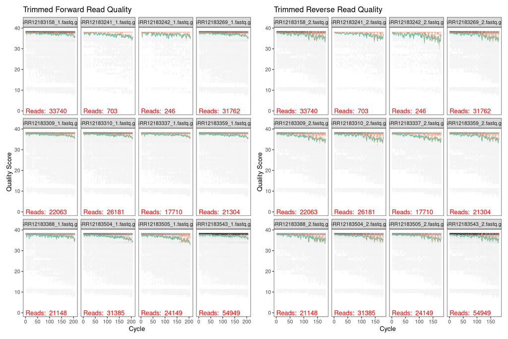

```r
# Plot the 12 random samples after QC
forward_filteredQual_plot_12 <-
  plotQualityProfile(filtered_forward_reads[random_sample]) +
  labs(title = "Trimmed Forward Read Quality")

reverse_filteredQual_plot_12 <-
  plotQualityProfile(filtered_reverse_reads[random_sample]) +
  labs(title = "Trimmed Reverse Read Quality")

# Put the two plots together
forward_filteredQual_plot_12 + reverse_filteredQual_plot_12
```

# Aggregated quality trimmed plots

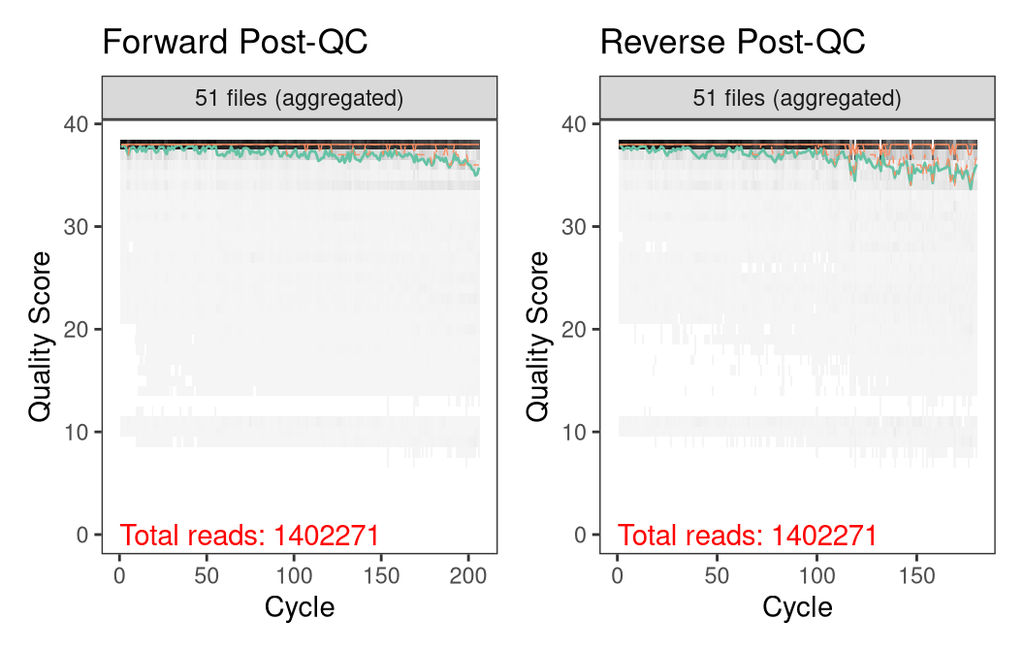

```r
# Aggregate all QC plots
# Forward reads
forward_postQC_plot <-
  plotQualityProfile(filtered_forward_reads, aggregate = TRUE) +
  labs(title = "Forward Post-QC")

# reverse reads
reverse_postQC_plot <-
  plotQualityProfile(filtered_reverse_reads, aggregate = TRUE) +
  labs(title = "Reverse Post-QC")

# Now, let's put the two plots together
postQC_aggregate_plot <-
  # Plot the forward and reverse together
  forward_postQC_plot + reverse_postQC_plot
# Show the plot
postQC_aggregate_plot
```

Interpretation of trimmed quality plot:

Forward reads post-qc:

- Super high quality throughout the read (>Q35)
- Slight, barely noticeable decline

Reverse reads post-qc:

- Some variation after 100 cycles/bases
- Still extremely high quality once trimmed (>Q33)

# Read retention

```r
# Make output into dataframe
filtered_df <- as.data.frame(filtered_reads) %>%
  mutate(percent.retained = reads.out/reads.in)

# Intuition check
# Visualize it in table format
DT::datatable(filtered_df)
```

|  | reads.in | reads.out | percent.retained |
| --- | --- | --- | --- |
| SRR12183139_1.fastq.gz | 39094 | 34722 | 0.8881669821455977 |
| SRR12183147_1.fastq.gz | 31501 | 28491 | 0.9044474778578457 |
| SRR12183158_1.fastq.gz | 37440 | 33740 | 0.9011752136752137 |
| SRR12183176_1.fastq.gz | 34105 | 29277 | 0.858437179299223 |
| SRR12183187_1.fastq.gz | 25656 | 21683 | 0.8451434362332398 |
| SRR12183204_1.fastq.gz | 24758 | 21376 | 0.8633976896356733 |
| SRR12183215_1.fastq.gz | 25938 | 22683 | 0.8745084432107333 |
| SRR12183228_1.fastq.gz | 53159 | 46213 | 0.8693353900562464 |
| SRR12183238_1.fastq.gz | 454 | 90 | 0.1982378854625551 |
| SRR12183239_1.fastq.gz | 42200 | 36943 | 0.8754265402843602 |

[output cut: 41 more lines]

```r
# Let's calculate some statistics
read_stats_df <-
  filtered_df %>%
  reframe(median_reads_in = median(reads.in),
          median_reads_out = median(reads.out),
          median_percent_retained = (median(reads.out)/median(reads.in)),
          max_percent_retained = max(reads.out/reads.in),
          min_percent_retained = min(reads.out/reads.in))

# Take a look at it!
read_stats_df
```

```
##   median_reads_in median_reads_out median_percent_retained max_percent_retained
## 1           31501            28491               0.9044475            0.9062782
##   min_percent_retained
## 1            0.1982379
```

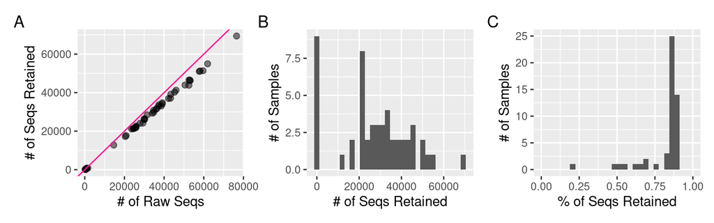

```r
# Plot it
numSeqs_QC_dotplot <-
  filtered_df %>%
  ggplot(aes(x = reads.in, y = reads.out)) +
  geom_point(alpha = 0.5, size = 2) +
  labs(x = "# of Raw Seqs",
       y = "# of Seqs Retained") +
  # Now let's add a 1:1 line for reference of keeping 100% of the reads
  geom_abline(slope=1, intercept = 0, color = "deeppink")

# Now, let's look at the number of reads retained in a histogram
numRetained_QC_histplot <-
  filtered_df %>%
  ggplot(aes(x = reads.out)) +
  geom_histogram() +
  labs(x = "# of Seqs Retained",
       y = "# of Samples")

# Create a histogram of percent reads retained in a histogram
percSeqs_QC_histplot <-
  filtered_df %>%
  ggplot(aes(x = percent.retained)) +
  geom_histogram() +
  labs(x = "% of Seqs Retained",
       y = "# of Samples") +
  # Set the scale to be between 0-1 (0-100%)
  scale_x_continuous(limits = c(0, 1))

# Now, let's put the plots together
numSeqs_QC_dotplot + numRetained_QC_histplot + percSeqs_QC_histplot +
  plot_annotation(tag_levels = 'A')
```

Interpretation of read retention plots:

Plot A:

- Most samples generally follow closely below the trend line, indicating some loss of seqs, but nothing excessive
- There are a number of samples clustered near the origin with low number of raw seqs and low retention

Plot B:

- Most samples have between 20k and 60k retained sequences.
- There is a spike close to 0 with samples with close to no reads
  - This will need to be looked at further and perhaps removed

Plot C:

- Most samples had over 75% of their sequences retained (median of 0.9044475! yay).
- There was a min retained percentage of 0.1982379, which may need to be investigated further

# Visualize pre/postQC

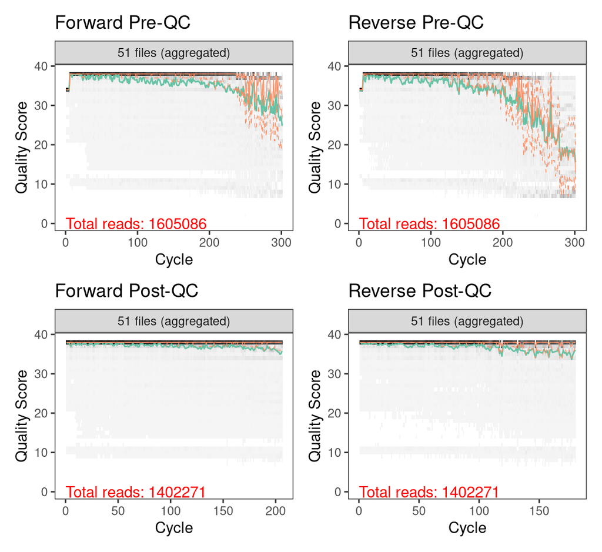

```r
# Plot the pre and post together in one plot
preQC_aggregate_plot / postQC_aggregate_plot
```

Interpretation of quality control effectiveness:

- I am overall satisfied with how qc turned out for both forward and reverse
- The first ~20 bp were trimmed since primers were left in during sequencing, which eliminated that small initial dip
- The middle is very strong still (>Q35)
- Although there is some degradation at the end, it is definitely not as severe as in the preQC plot for both forward and reverse. The Phred score is still maintained at above Q30 over the entire read.

I think I have sufficiently QC’d my data, and I trust its quality!!!